# CCE_Lab1

Ryan Peckner

June 30,2021

#### SECTION 1

We are interested in computing the global average temperature increase above pre-industrial times in °C at a given time t. We’ll start by loading the data into a dataframe called ‘forcings’, where we will also deposit all the results of our calculations.

```r
library(readxl,quietly = T)
suppressMessages({forcings_excel = read_xlsx("CCE - Assignment 1 - Forcings.xlsx",skip = 1)})
forcings = data.frame(year = as.integer(forcings_excel[1,][-1]),co2 = as.numeric(forcings_excel[4,][-1]),
                        rfOther = as.numeric(forcings_excel[5,][-1]),emissions = as.numeric(forcings_excel[8,][-1]))
head(forcings)
```

|  | year | co2 | rfOther | emissions |
| --- | --- | --- | --- | --- |
| 1 | 2010 | 380.3290 | 0.8300000 | 7626.003 |
| 2 | 2011 | 381.3423 | 0.8241111 | 7709.800 |
| 3 | 2012 | 383.3699 | 0.8182222 | 7794.723 |
| 4 | 2013 | 385.4130 | 0.8123333 | 7883.785 |
| 5 | 2014 | 387.4731 | 0.8064444 | 7976.030 |
| 6 | 2015 | 389.5514 | 0.8005556 | 8071.568 |

Next, we’ll fix the values of various parameters described in the handout. We’ll then write functions to compute the essential variables in the model as functions of the timepoint t.

```r
C_pre = 275 # Pre-industrial atmospheric CO2 level
lambda = 0.8 # Climate sensitivity
mu = 1/66 # Warming delay parameter
T_2010 = 0.8

RadiativeForcingCO2 = function(t,CO2) {
  return(5.35*log(CO2[t]/C_pre))}  # Note that R uses the natural logarithm by default

RadiativeForcingTotal = function(t,CO2) {
  RadiativeForcingCO2(t,CO2) + forcings$rfOther[t]
  }

GlobalAvgTempIncrease_ConstantRF = function(t,CO2) {
  lambda*RadiativeForcingTotal(t,CO2)
  }
```

Now, the global average temperature increase above pre-industrial times is computed via a recursive delay model. So we will use a recursive R function to compute it. Since recursion has an exponential running time, we will use memoisation to store the results of each function call.

```r
library(memoise,quietly = T)
GlobalAvgTempIncrease = memoise(function(t,CO2) {
  if (t == 1) return(T_2010)
  else        return(GlobalAvgTempIncrease(t-1,CO2) +
                       mu*(GlobalAvgTempIncrease_ConstantRF(t,CO2) - GlobalAvgTempIncrease(t-1,CO2)))

})
```

Now we compute the global average temperature increase at each time point, and add these values to our dataframe containing the input variables.

```r
forcings$TempIncrease = sapply(1:nrow(forcings),GlobalAvgTempIncrease,
                               CO2 = forcings$co2)
forcings$TempIncrease_ConstantCO2 = sapply(1:nrow(forcings),GlobalAvgTempIncrease,CO2 = rep(forcings$co2[1],
                                                          nrow(forcings)))
head(forcings)
```

|  | year | co2 | rfOther | emissions | TempIncrease | TempIncrease_ConstantCO2 |
| --- | --- | --- | --- | --- | --- | --- |
| 1 | 2010 | 380.3290 | 0.8300000 | 7626.003 | 0.8000000 | 0.8000000 |
| 2 | 2011 | 381.3423 | 0.8241111 | 7709.800 | 0.8190687 | 0.8188961 |
| 3 | 2012 | 383.3699 | 0.8182222 | 7794.723 | 0.8381210 | 0.8374346 |
| 4 | 2013 | 385.4130 | 0.8123333 | 7883.785 | 0.8571579 | 0.8556208 |
| 5 | 2014 | 387.4731 | 0.8064444 | 7976.030 | 0.8761807 | 0.8734601 |
| 6 | 2015 | 389.5514 | 0.8005556 | 8071.568 | 0.8951907 | 0.8909577 |

**Question 1a** *What happens to projected temperature if CO2 concentrations were held constant at 2010 levels in the model?*

In this case, the radiative forcing due to CO2 does not change with time, so any change in the total radiative forcing is due only to non-CO2 greenhouse gases. This non-CO2 radiative forcing decreases sharply with time and eventually stabilizes to a value of 0.3, beginning in year 2100:

```r
#install.packages("extrafontdb",repos=getOption("repos"))
#devtools::install_github("hrbrmstr/hrbrthemes", force = TRUE)
library(ggplot2,quietly = T)
hrbrthemes::import_roboto_condensed()

library(hrbrthemes, quietly = T)
d <- read.csv(extrafont:::fonttable_file(), stringsAsFactors = FALSE)
d[grepl("Light", d$FontName),]$FamilyName <- font_rc_light
write.csv(d,extrafont:::fonttable_file(), row.names = FALSE)
extrafont::loadfonts()
```

```
## Registering font with R using pdfFonts(): Roboto Condensed
```

```
## Registering font with R using pdfFonts(): Roboto Condensed Light
```

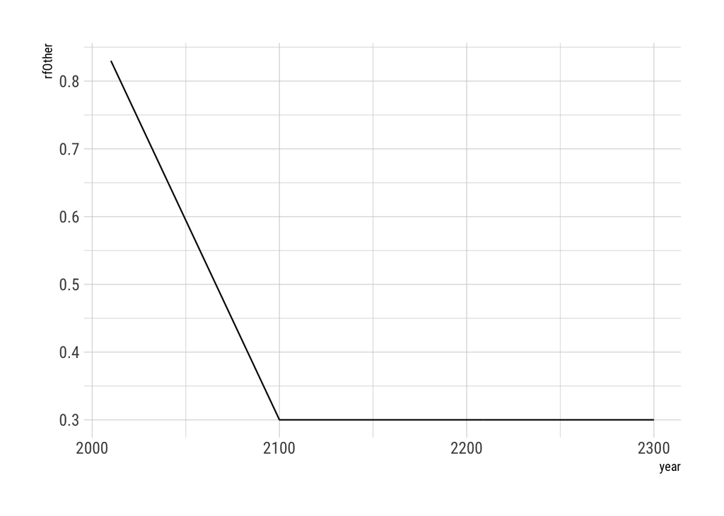

```r
library(gcookbook,quietly = T)

ggplot(forcings,aes(x=year,y=rfOther)) + geom_line() + theme_ipsum_rc()
```

While this implies that the *rate* of temperature increase above pre-industrial levels will begin to decline quickly, the persistence of greenhouse gases means that temperatures will continue to rise until 2300, albeit at a slower rate than if CO2 emissions were to continue increasing.

**Question 1b** *Create two graphs, one for CO2 concentrations and one for temperature. The x-axis should have years on it for both graphs. Then plot each of the two cases analyzed (base case and constant concentrations) as one line.*

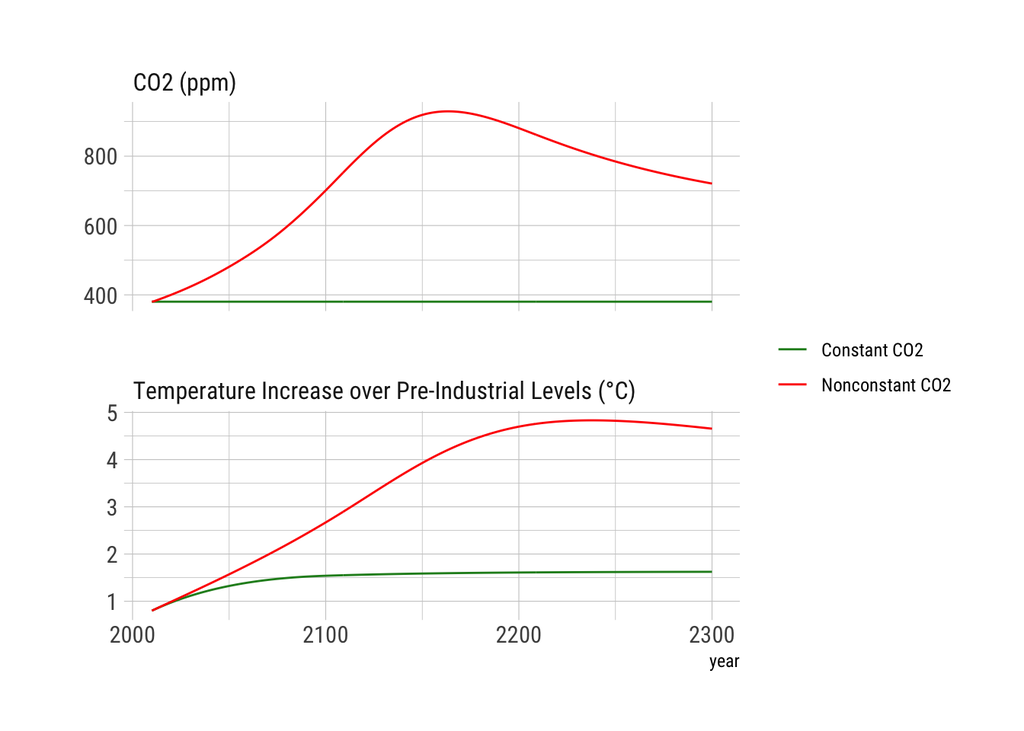

```r
library(reshape2,quietly = T)
library(gridExtra,quietly = T)

forcings$ConstantCO2 = forcings$co2[1]
df_plot = melt(forcings[c("year","co2","ConstantCO2","TempIncrease","TempIncrease_ConstantCO2")],id.vars="year")
df_plot$type = ifelse(grepl("Temp",df_plot$variable),"Temperature Increase over Pre-Industrial Levels (°C)","CO2 (ppm)")
df_plot$group = ifelse(grepl("Constant",df_plot$variable),"Constant CO2","Nonconstant CO2")

g_temp = ggplot(df_plot,aes(x=year,y=value)) +
              facet_wrap(~type,scales="free_y",ncol=1) +
              geom_line(aes(color=group)) +
            ylab("") +
            scale_color_manual(values=c("forestgreen","red"),
                               labels = c("Constant CO2","Nonconstant CO2")) +
            theme_ipsum_rc() +
            theme(legend.title = element_blank())

g_temp
```

#### SECTION 2

First, we will initialize the parameters given in the modeling section, then create variables representing each of the five boxes.

```r
alpha = c(1,exp(-1/363),exp(-1/74),exp(-1/17),exp(-1/2))
gamma = c(0.13,0.2,0.32,0.25,0.1)
Box2010 = c(301.099,30.098,34.878,12.357,0.897)
beta = 0.00047

Box = memoise(function(i,t) {
  if (t == 1) return(Box2010[i])
  else return(alpha[i]*Box(i,t-1) + gamma[i]*beta*forcings$emissions[t])
})


AtmosphericCO2 = function(t) {
  return(Box(1,t) + Box(2,t) + Box(3,t) + Box(4,t) + Box(5,t))
}
```

Now, we will add a column to our dataframe containing the outputs from this carbon cycle model.

```r
forcings$CarbonCycleModelCO2 = sapply(1:nrow(forcings),AtmosphericCO2)
head(forcings)
```

|  | year | co2 | rfOther | emissions | TempIncrease | TempIncrease_ConstantCO2 | ConstantCO2 | CarbonCycleModelCO2 |
| --- | --- | --- | --- | --- | --- | --- | --- | --- |
| 1 | 2010 | 380.3290 | 0.8300000 | 7626.003 | 0.8000000 | 0.8000000 | 380.329 | 379.3290 |
| 2 | 2011 | 381.3423 | 0.8241111 | 7709.800 | 0.8190687 | 0.8188961 | 380.329 | 381.3428 |
| 3 | 2012 | 383.3699 | 0.8182222 | 7794.723 | 0.8381210 | 0.8374346 | 380.329 | 383.3703 |
| 4 | 2013 | 385.4130 | 0.8123333 | 7883.785 | 0.8571579 | 0.8556208 | 380.329 | 385.4134 |
| 5 | 2014 | 387.4731 | 0.8064444 | 7976.030 | 0.8761807 | 0.8734601 | 380.329 | 387.4735 |
| 6 | 2015 | 389.5514 | 0.8005556 | 8071.568 | 0.8951907 | 0.8909577 | 380.329 | 389.5518 |

**Question 1c** *What happens to projected temperature if CO2 emissions were held constant at 2010 levels in the model?*

The persistence of atmospheric CO2 (reflected by the recursive term in the delay model) implies that projected temperatures will continue to rise even if CO2 emissions are held constant, albeit at a slower rate than if CO2 emissions were to continue increasing.

**Question 1d** *By how much % would we need to reduce emissions in each year to keep global warming below 2° over the next 300 years?*

For this, we will rewrite the model to accept arbitrary emission values instead of those supplied in the Excel sheet.

```r
Box = memoise(function(i,t,emissions) {
  if (t == 1) return(Box2010[i])
  else return(alpha[i]*Box(i,t-1,emissions) + gamma[i]*beta*emissions[t])
})


AtmosphericCO2 = function(t,emissions) {
  return(Box(1,t,emissions) + Box(2,t,emissions) + Box(3,t,emissions) + Box(4,t,emissions) + Box(5,t,emissions))
}
```

We want to ensure that global warming doesn’t exceed 2°C over the next 300 years. We’ll calculate the emissions threshold that would need to be maintained to prevent this increase. For this, supply the output of the carbon cycle model as the input to the climate dynamics model from Section 1.

```r
CarbonCycleModelCO2 = function(emissions) {
  sapply(1:nrow(forcings),AtmosphericCO2,emissions=emissions)
}

GlobalAvgTempIncrease_FromEmissions = memoise(function(t,emissions) {
  GlobalAvgTempIncrease(t,CarbonCycleModelCO2(emissions))
})
```

As a sanity check, let’s make sure that the average temperature increase calculated in this fashion agrees with the results from the model when we input the original emissions. Since it isn’t reasonable to expect exact agreement given the approximations involved in each approach, let’s instead look at the distribution of the magnitudes of the differences between the results for each timepoint.

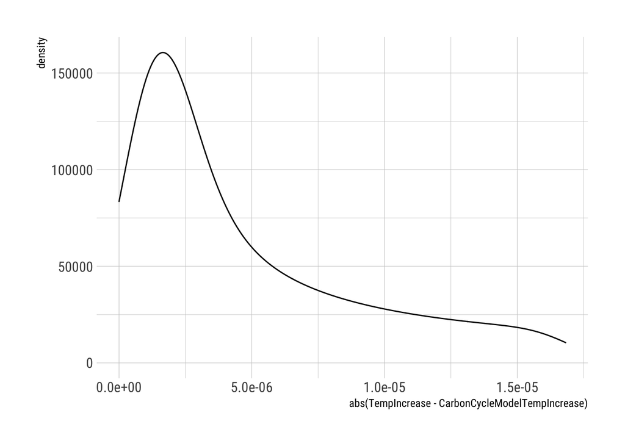

```r
forcings$CarbonCycleModelCO2 = CarbonCycleModelCO2(forcings$emissions)
forcings$CarbonCycleModelTempIncrease = sapply(1:nrow(forcings),
                                               GlobalAvgTempIncrease_FromEmissions,
                                               emissions=forcings$emissions)
ggplot(forcings,aes(abs(TempIncrease - CarbonCycleModelTempIncrease))) + geom_density() + theme_ipsum_rc()
```

We see that the differences are extremely small relative to temperature, so the carbon cycle model does seem to accurately predict the temperature effects of emissions.

Let’s introduce some functions to calculate the relevant parameters of the model - in particular, the effect on temperature increase of a given percent reduction in CO2 emissions.

```r
ReducedEmissions = memoise(function(t,percent_reduction) {
  if (t == 1) return(forcings$emissions[1])
  else return(ReducedEmissions(t-1,percent_reduction)*(1-percent_reduction))
})

ReducedEmissionsProfile = function(percent_reduction) {
  sapply(1:nrow(forcings),ReducedEmissions,percent_reduction=percent_reduction)
}

TempIncrease_ReducedEmissions = function(t,percent_reduction) {
  return(GlobalAvgTempIncrease_FromEmissions(t,ReducedEmissionsProfile(percent_reduction)))
}

MaxTempIncrease = function(percent_reduction) {
  return(max(sapply(1:nrow(forcings),TempIncrease_ReducedEmissions,percent_reduction)))
}
```

Now, we wish to calculate the minimum annual percent reduction in emissions that will keep the temperature increase below 2°C for all timepoints. We’ll compute this with a simple root-finding algorithm.

```r
RequiredPercentReduction = uniroot(function(p) MaxTempIncrease(p) - 2,interval=c(0,1))
print(RequiredPercentReduction$root)
```

```
## [1] 0.01318409
```

We see that we would need an annual emissions reduction of around **1.3%** (beginning in 2011) to maintain a temperature increase below 2°C until 2300. Let’s add the reduced emissions profile and associated atmospheric carbon concentrations and temperature increases to our master dataframe for future reference.

```r
forcings$ReducedEmissions2010 = ReducedEmissionsProfile(RequiredPercentReduction$root)
forcings$AtmosphericCO2_ReducedEmissions2010 = CarbonCycleModelCO2(forcings$ReducedEmissions2010)
forcings$TempIncrease_ReducedEmissions2010 = sapply(1:nrow(forcings),
                                                    TempIncrease_ReducedEmissions,
                                                    percent_reduction=RequiredPercentReduction$root)
```

**Question 1e** *If emissions stay as they are specified in base case until the year 2049, and are then reduced by a fixed percent each year, how much would they have to be reduced in percent in each year to keep global warming below 2° over the next 300 years?*

We will recycle the same code from above, but supply the model with the base case emissions levels until 2049.

```r
ReducedEmissions = memoise(function(t,percent_reduction) {
  if (t <= 39) return(forcings$emissions[t])
  else return(ReducedEmissions(t-1,percent_reduction)*(1-percent_reduction))
})

ReducedEmissionsProfile = function(percent_reduction) {
  sapply(1:nrow(forcings),ReducedEmissions,percent_reduction=percent_reduction)
}

TempIncrease_ReducedEmissions = function(t,percent_reduction) {
  return(GlobalAvgTempIncrease_FromEmissions(t,ReducedEmissionsProfile(percent_reduction)))
}

MaxTempIncrease = function(percent_reduction) {
  return(max(sapply(1:nrow(forcings),TempIncrease_ReducedEmissions,percent_reduction)))
}
```

Again, we use root-finding to identify the desired minimal percent reduction.

```r
RequiredPercentReduction = uniroot(function(p) MaxTempIncrease(p) - 2,interval=c(0,1))
print(RequiredPercentReduction$root)
```

```
## [1] 0.2307607
```

We see that we would need an annual emissions reduction of around **23%** to maintain a temperature increase below 2°C until 2300 if the base case emissions are released until 2049. Again, we add this information to our dataframe for reference.

```r
forcings$ReducedEmissions2050 = ReducedEmissionsProfile(RequiredPercentReduction$root)
forcings$AtmosphericCO2_ReducedEmissions2050 = CarbonCycleModelCO2(forcings$ReducedEmissions2050)
forcings$TempIncrease_ReducedEmissions2050 = sapply(1:nrow(forcings),
                                                    TempIncrease_ReducedEmissions,
                                                    percent_reduction=RequiredPercentReduction$root)
```

**Question 1f** *Create three graphs, one for CO2 emissions, one for CO2 concentrations and one for temperature. The x-axis should have years on it for all three graphs. Then plot each of the four cases analyzed (base case, constant emissions, reduction in emissions starting now, reduction in emissions starting in 2050) as one line.*

```r
library(dplyr,quietly = TRUE)
```

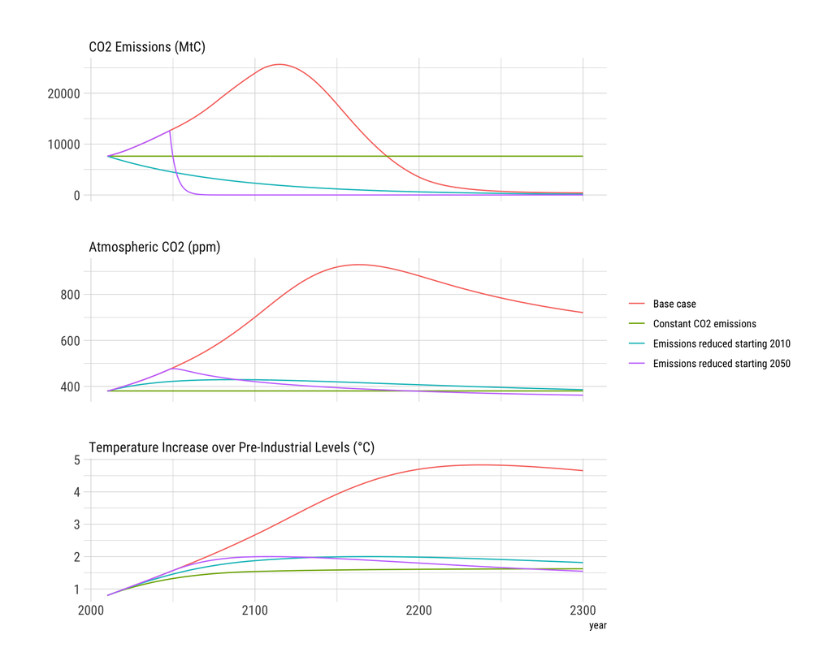

```r
forcings$ConstantEmissions = forcings$emissions[1]
forcings = rename(forcings,BaseCaseEmissions = emissions,BaseCaseAtmosphericCO2 = co2, BaseCaseTempIncrease = TempIncrease)
df_plot = melt(forcings[c("year","BaseCaseEmissions","ConstantEmissions","ReducedEmissions2010","ReducedEmissions2050",
                          "BaseCaseAtmosphericCO2","ConstantCO2","AtmosphericCO2_ReducedEmissions2010","AtmosphericCO2_ReducedEmissions2050",
                          "BaseCaseTempIncrease","TempIncrease_ConstantCO2",
                          "TempIncrease_ReducedEmissions2010","TempIncrease_ReducedEmissions2050")],
                        id.vars="year")

df_plot$type = "CO2 Emissions (MtC)"
df_plot$type[grep("CO2",df_plot$variable)] = "Atmospheric CO2 (ppm)"
df_plot$type[grep("Temp",df_plot$variable)] = "Temperature Increase over Pre-Industrial Levels (°C)"


df_plot$type = factor(df_plot$type,levels=c("CO2 Emissions (MtC)","Atmospheric CO2 (ppm)","Temperature Increase over Pre-Industrial Levels (°C)"))
 # Make sure emissions get plotted first

df_plot$reduction = "Base case"
df_plot$reduction[grep("Constant",df_plot$variable)] = "Constant CO2 emissions"
df_plot$reduction[grep("ReducedEmissions2010",df_plot$variable)] = "Emissions reduced starting 2010"
df_plot$reduction[grep("ReducedEmissions2050",df_plot$variable)] = "Emissions reduced starting 2050"

g_temp = ggplot(df_plot,aes(x=year,y=value)) +
              facet_wrap(~type,scales="free_y",ncol=1) +
              geom_line(aes(group=variable,color=reduction)) +
            ylab("") +
            theme_ipsum_rc() +
            theme(legend.title = element_blank())

g_temp
```